# odin discrete models

Thibaut Jombart, Rich FitzJohn

2025-02-07

# Discrete compartmental models in a nutshell

## From continuous to discrete time

In its simplest form, a SIR model is typically written in continuous time as:

$$\frac{dS}{dt} = - \beta \frac{S_t I_t}{N_t}$$

$$\frac{dI}{dt} = \beta \frac{S_t I_t}{N_t} - \gamma I_t$$

$$\frac{dR}{dt} = \gamma I_t$$

Where $\beta$ is an infection rate and $\gamma$ a removal rate, assuming ‘R’ stands for ‘recovered’, which can mean recovery or death.

For discrete time equivalent, we take a small time step $t$ (typically a day), and write the changes of individuals in each compartment as:

$$S_{t+1} = S_t - \beta \frac{S_t I_t}{N_t}$$

$$I_{t+1} = I_t + \beta \frac{S_t I_t}{N_t} - \gamma I_t$$

$$R_{t+1} = R_t + \gamma I_t$$

## Stochastic processes

The discrete model above remains deterministic: for given values of the rates $\beta$ and $\gamma$, dynamics will be fixed. It is fairly straightforward to convert this discrete model into a stochastic one: one merely needs to uses appropriate probability distributions to model the transfer of individuals across compartments. There are at least 3 types of such distributions which will be useful to consider.

### Binomial distribution

This distribution will be used to determine numbers of individuals **leaving** a given compartment. While we may be tempted to use a Poisson distribution with the rates specified in the equations above, this could lead to over-shooting, i.e. more individuals leaving a compartment than there actually are. To avoid infecting more people than there are susceptibles, we use a binomial distribution, with one draw for each individual in the compartment of interest. The workflow will be:

1. determine a *per-capita probability* of leaving the compartment, based on the original rates specified in the equations; if the rate at which each individual leaves a compartment is $\lambda$, then the corresponding probability of this individual leaving the compartment in one time unit is $p = 1 - e^{- \lambda}$.
2. determine the number of individuals leaving the compartment using a *Binomial* distribution, with one draw per individual and a probability $p$

As an example, let us consider transition $S \rightarrow I$ in the SIR model. The overall rate at which this change happens is $\beta \frac{S_t I_t}{N_t}$. The corresponding *per susceptible* rate is $\beta \frac{I_t}{N_t}$. Therefore, the probability for an individual to move from *S* to *I* at time $t$ is $p_{(S \rightarrow I), t} = 1 - e^{- \beta \frac{I_t}{N_t}}$.

### Poisson distribution

Poisson distributions will be useful when individuals enter a compartment at a given rate, from ‘the outside’. This could be birth or migration (for $S$), or introduction of infections from an external reservoir (for $I$), etc. The essential distinction with the previous process is that individuals are *not leaving* an existing compartment.

This case is simple to handle: one just needs to draw new individuals entering the compartment from a Poisson distribution with the rate directly coming from the equations.

For instance, let us now consider a variant of the SIR model where new infectious cases are imported at a constant rate $\epsilon$. The only change to the equation is for the infected compartment:

$$I_{t+1} = I_t + \beta \frac{S_t I_t}{N_t} + \epsilon - \gamma I_t$$

where:

- individuals move from $S$ to $I$ according to a Binomial distribution $\mathcal{B}(S_t, 1 - e^{- \beta \frac{I_t}{N_t}})$
- new infected individuals are imported according to a Poisson distribution $\mathcal{P}(\epsilon)$
- individual move from $I$ to $R$ according to a Binomial distribution $\mathcal{B}(I_t, 1 - e^{- \gamma})$

### Multinomial distribution

This distribution will be useful when individuals leaving a compartment are distributed over several compartments. The Multinomial distribution will be used to determine how many individuals end up in each compartment. Let us assume that individuals move from a compartment $X$ to compartments $A$, $B$, and $C$, at rates $\lambda_A$, $\lambda_B$ and $\lambda_C$. The workflow to handle these transitions will be:

1. determine the total number of individuals leaving $X$; this is done by summing the rates ($\lambda = \lambda_A + \lambda_B + \lambda_C$) to compute the *per capita* probability of leaving $X$ $(p_(X \rightarrow ...) = 1 - e^{- \lambda})$, and drawing the number of individuals leaving $X$ ($n_{_(X \rightarrow ...)}$) from a binomial distribution $n_{(X \rightarrow ...)} \sim B(X, p_(X \rightarrow ...))$
2. compute relative probabilities of moving to the different compartments (using $i$ as a placeholder for $A$, $B$, $C$): $p_i = \frac{\lambda_i}{\sum_i \lambda_i}$
3. determine the numbers of individuals moving to $A$, $B$ and $C$ using a Multinomial distribution: $n_{(X \rightarrow A, B, C)} \sim \mathcal{M}(n_{(X \rightarrow ...)}, p_A, p_B, p_C)$

# Implementation using `odin`

## Deterministic SIR model

```r
path_sir_model <- system.file("examples/discrete_deterministic_sir.R", package = "odin")
```

```r
## Core equations for transitions between compartments:
update(S) <- S - beta * S * I / N
update(I) <- I + beta * S * I / N - gamma * I
update(R) <- R + gamma * I

## Total population size (odin will recompute this at each timestep:
## automatically)
N <- S + I + R

## Initial states:
initial(S) <- S_ini # will be user-defined
initial(I) <- I_ini # will be user-defined
initial(R) <- 0

## User defined parameters - default in parentheses:
S_ini <- user(1000)
I_ini <- user(1)
beta <- user(0.2)
gamma <- user(0.1)
```

As said in the previous vignette, remember this looks and parses like R code, but is not actually R code. Copy-pasting this in a R session will trigger errors.

We then use `odin` to compile this model:

```r
sir_generator <- odin::odin(path_sir_model)
sir_generator
```

```
## <odin_model> object generator
##   Public:
##     initialize: function (..., user = list(...), use_dde = FALSE, unused_user_action = NULL)
##     ir: function ()
##     set_user: function (..., user = list(...), unused_user_action = NULL)
##     initial: function (step)
##     rhs: function (step, y)
##     update: function (step, y)
##     contents: function ()
##     transform_variables: function (y)
##     run: function (step, y = NULL, ..., use_names = TRUE)
##   Private:
##     ptr: NULL
##     use_dde: NULL
##     odin: NULL
##     variable_order: NULL
##     output_order: NULL
##     n_out: NULL
##     ynames: NULL
##     interpolate_t: NULL
##     cfuns: list
##     dll: discrete.deterministic.sir4de329d6
##     user: I_ini S_ini beta gamma
##     registration: function ()
##     set_initial: function (step, y, use_dde)
##     update_metadata: function ()
##   Parent env: <environment: namespace:discrete.deterministic.sir4de329d6>
##   Locked objects: TRUE
##   Locked class: FALSE
##   Portable: TRUE
```

**Note**: this is the slow part (generation and then compilation of C code)! Which means for computer-intensive work, the number of times this is done should be minimized.

The returned object `sir_generator`is an R6 generator that can be used to create an instance of the model: generate an instance of the model:

```r
x <- sir_generator$new()
x
```

```
## <odin_model>
##   Public:
##     contents: function ()
##     initial: function (step)
##     initialize: function (..., user = list(...), use_dde = FALSE, unused_user_action = NULL)
##     ir: function ()
##     rhs: function (step, y)
##     run: function (step, y = NULL, ..., use_names = TRUE)
##     set_user: function (..., user = list(...), unused_user_action = NULL)
##     transform_variables: function (y)
##     update: function (step, y)
##   Private:
##     cfuns: list
##     dll: discrete.deterministic.sir4de329d6
##     interpolate_t: NULL
##     n_out: 0
##     odin: environment
##     output_order: NULL
##     ptr: externalptr
##     registration: function ()
##     set_initial: function (step, y, use_dde)
##     update_metadata: function ()
##     use_dde: FALSE
##     user: I_ini S_ini beta gamma
##     variable_order: list
##     ynames: step S I R
```

```r
sir_col <- c("#8c8cd9", "#cc0044", "#999966")
x$run(0:10)
```

```
##       step         S        I         R
##  [1,]    0 1000.0000 1.000000 0.0000000
##  [2,]    1  999.8002 1.099800 0.1000000
##  [3,]    2  999.5805 1.209517 0.2099800
##  [4,]    3  999.3389 1.330125 0.3309317
##  [5,]    4  999.0734 1.462696 0.4639442
##  [6,]    5  998.7814 1.608403 0.6102138
##  [7,]    6  998.4604 1.768530 0.7710541
##  [8,]    7  998.1076 1.944486 0.9479071
##  [9,]    8  997.7198 2.137811 1.1423557
## [10,]    9  997.2937 2.350191 1.3561368
## [11,]   10  996.8254 2.583469 1.5911558
```

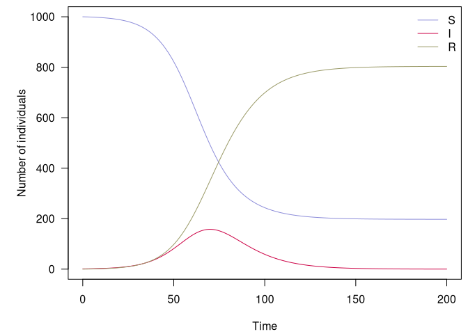

*An example of deterministic, discrete-time SIR model*

```r
x_res <- x$run(0:200)
par(mar = c(4.1, 5.1, 0.5, 0.5), las = 1)
matplot(x_res[, 1], x_res[, -1], xlab = "Time", ylab = "Number of individuals",
        type = "l", col = sir_col, lty = 1)
legend("topright", lwd = 1, col = sir_col, legend = c("S", "I", "R"), bty = "n")
```

## Stochastic SIR model

The stochastic equivalent of the previous model can be formulated in `odin` as follows:

```r
path_sir_model_s <- system.file("examples/discrete_stochastic_sir.R", package = "odin")
```

```r
## Core equations for transitions between compartments:
update(S) <- S - n_SI
update(I) <- I + n_SI - n_IR
update(R) <- R + n_IR

## Individual probabilities of transition:
p_SI <- 1 - exp(-beta * I / N) # S to I
p_IR <- 1 - exp(-gamma) # I to R

## Draws from binomial distributions for numbers changing between
## compartments:
n_SI <- rbinom(S, p_SI)
n_IR <- rbinom(I, p_IR)

## Total population size
N <- S + I + R

## Initial states:
initial(S) <- S_ini
initial(I) <- I_ini
initial(R) <- 0

## User defined parameters - default in parentheses:
S_ini <- user(1000)
I_ini <- user(1)
beta <- user(0.2)
gamma <- user(0.1)
```

We can use the same workflow as before to run the model, using 10 initial infected individuals (`I_ini = 10`):

```r
sir_s_generator <- odin::odin(path_sir_model_s)
sir_s_generator
```

```
## <odin_model> object generator
##   Public:
##     initialize: function (..., user = list(...), use_dde = FALSE, unused_user_action = NULL)
##     ir: function ()
##     set_user: function (..., user = list(...), unused_user_action = NULL)
##     initial: function (step)
##     rhs: function (step, y)
##     update: function (step, y)
##     contents: function ()
##     transform_variables: function (y)
##     run: function (step, y = NULL, ..., use_names = TRUE)
##   Private:
##     ptr: NULL
##     use_dde: NULL
##     odin: NULL
##     variable_order: NULL
##     output_order: NULL
##     n_out: NULL
##     ynames: NULL
##     interpolate_t: NULL
##     cfuns: list
##     dll: discrete.stochastic.sir09143884
##     user: I_ini S_ini beta gamma
##     registration: function ()
##     set_initial: function (step, y, use_dde)
##     update_metadata: function ()
##   Parent env: <environment: namespace:discrete.stochastic.sir09143884>
##   Locked objects: TRUE
##   Locked class: FALSE
##   Portable: TRUE
```

```r
x <- sir_s_generator$new(I_ini = 10)
```

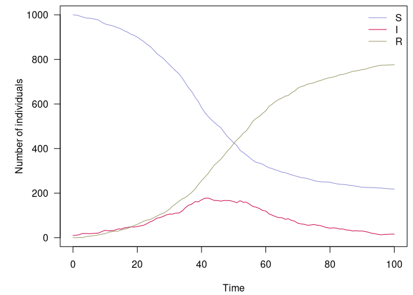

*An example of stochastic, discrete-time SIR model*

```r
set.seed(1)
x_res <- x$run(0:100)
par(mar = c(4.1, 5.1, 0.5, 0.5), las = 1)
matplot(x_res[, 1], x_res[, -1], xlab = "Time", ylab = "Number of individuals",
        type = "l", col = sir_col, lty = 1)
legend("topright", lwd = 1, col = sir_col, legend = c("S", "I", "R"), bty = "n")
```

This gives us a single stochastic realisation of the model, which is of limited interest. As an alternative, we can generate a large number of replicates using arrays for each compartment:

```r
path_sir_model_s_a <- system.file("examples/discrete_stochastic_sir_arrays.R", package = "odin")
```

```r
## Core equations for transitions between compartments:
update(S[]) <- S[i] - n_SI[i]
update(I[]) <- I[i] + n_SI[i] - n_IR[i]
update(R[]) <- R[i] + n_IR[i]

## Individual probabilities of transition:
p_SI[] <- 1 - exp(-beta * I[i] / N[i])
p_IR <- 1 - exp(-gamma)

## Draws from binomial distributions for numbers changing between
## compartments:
n_SI[] <- rbinom(S[i], p_SI[i])
n_IR[] <- rbinom(I[i], p_IR)

## Total population size
N[] <- S[i] + I[i] + R[i]

## Initial states:
initial(S[]) <- S_ini
initial(I[]) <- I_ini
initial(R[]) <- 0

## User defined parameters - default in parentheses:
S_ini <- user(1000)
I_ini <- user(1)
beta <- user(0.2)
gamma <- user(0.1)

## Number of replicates
nsim <- user(100)
dim(N) <- nsim
dim(S) <- nsim
dim(I) <- nsim
dim(R) <- nsim
dim(p_SI) <- nsim
dim(n_SI) <- nsim
dim(n_IR) <- nsim
```

```r
sir_s_a_generator <- odin::odin(path_sir_model_s_a)
sir_s_a_generator
```

```
## <odin_model> object generator
##   Public:
##     initialize: function (..., user = list(...), use_dde = FALSE, unused_user_action = NULL)
##     ir: function ()
##     set_user: function (..., user = list(...), unused_user_action = NULL)
##     initial: function (step)
##     rhs: function (step, y)
##     update: function (step, y)
##     contents: function ()
##     transform_variables: function (y)
##     run: function (step, y = NULL, ..., use_names = TRUE)
##   Private:
##     ptr: NULL
##     use_dde: NULL
##     odin: NULL
##     variable_order: NULL
##     output_order: NULL
##     n_out: NULL
##     ynames: NULL
##     interpolate_t: NULL
##     cfuns: list
##     dll: discrete.stochastic.sir.arraysb818bd3a
##     user: I_ini S_ini beta gamma nsim
##     registration: function ()
##     set_initial: function (step, y, use_dde)
##     update_metadata: function ()
##   Parent env: <environment: namespace:discrete.stochastic.sir.arraysb818bd3a>
##   Locked objects: TRUE
##   Locked class: FALSE
##   Portable: TRUE
```

```r
x <- sir_s_a_generator$new()
```

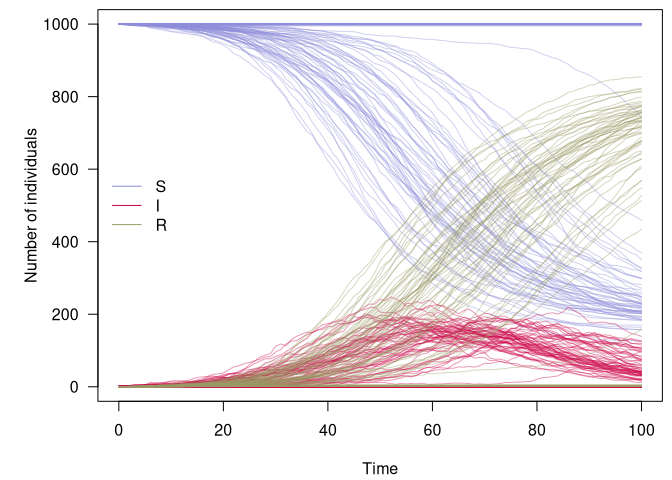

*100 replicates of a stochastic, discrete-time SIR model*

```r
set.seed(1)
sir_col_transp <- paste0(sir_col, "66")
x_res <- x$run(0:100)
par(mar = c(4.1, 5.1, 0.5, 0.5), las = 1)
matplot(x_res[, 1], x_res[, -1], xlab = "Time", ylab = "Number of individuals",
        type = "l", col = rep(sir_col_transp, each = 100), lty = 1)
legend("left", lwd = 1, col = sir_col, legend = c("S", "I", "R"), bty = "n")
```

## A stochastic SEIRDS model

This model is a more complex version of the previous one, which we will use to illustrate the use of all distributions mentioned in the first part: Binomial, Poisson and Multinomial.

The model is contains the following compartments:

- $S$: susceptibles
- $E$: exposed, i.e. infected but not yet contagious
- $I_R$: infectious who will survive
- $I_D$: infectious who will die
- $R$: recovered
- $D$: dead

There are no birth of natural death processes in this model. Parameters are:

- $\beta$: rate of infection
- $\delta$: rate at which symptoms appear (i.e inverse of mean incubation period)
- $\gamma_R$: recovery rate
- $\gamma_D$: death rate
- $\mu$: case fatality ratio (proportion of cases who die)
- $\epsilon$: import rate of infected individuals (applies to $E$ and $I$)
- $\omega$: rate waning immunity

The model will be written as:

$$S_{t+1} = S_t - \beta \frac{S_t (I_{R,t} + I_{D,t})}{N_t} + \omega R_t$$

$$E_{t+1} = E_t + \beta \frac{S_t (I_{R,t} + I_{D,t})}{N_t} - \delta E_t +
\epsilon$$

$$I_{R,t+1} = I_{R,t} + \delta (1 - \mu) E_t - \gamma_R I_{R,t} + \epsilon$$

$$I_{D,t+1} = I_{D,t} + \delta \mu E_t - \gamma_D I_{D,t} + \epsilon$$

$$R_{t+1} = R_t + \gamma_R I_{R,t} - \omega R_t$$

$$D_{t+1} = D_t + \gamma_D I_{D,t}$$

The formulation of the model in `odin` is:

```r
path_seirds_model <- system.file("examples/discrete_stochastic_seirds.R", package = "odin")
```

```r
## Core equations for transitions between compartments:
update(S) <- S - n_SE + n_RS
update(E) <- E + n_SE - n_EI + n_import_E
update(Ir) <- Ir + n_EIr - n_IrR
update(Id) <- Id + n_EId - n_IdD
update(R) <- R + n_IrR - n_RS
update(D) <- D + n_IdD

## Individual probabilities of transition:
p_SE <- 1 - exp(-beta * I / N)
p_EI <-  1 - exp(-delta)
p_IrR <- 1 - exp(-gamma_R) # Ir to R
p_IdD <- 1 - exp(-gamma_D) # Id to d
p_RS <- 1 - exp(-omega) # R to S


## Draws from binomial distributions for numbers changing between
## compartments:
n_SE <- rbinom(S, p_SE)
n_EI <- rbinom(E, p_EI)

n_EIrId[] <- rmultinom(n_EI, p)
p[1] <- 1 - mu
p[2] <- mu
dim(p) <- 2
dim(n_EIrId) <- 2
n_EIr <- n_EIrId[1]
n_EId <- n_EIrId[2]
n_IrR <- rbinom(Ir, p_IrR)
n_IdD <- rbinom(Id, p_IdD)

n_RS <- rbinom(R, p_RS)

n_import_E <- rpois(epsilon)

## Total population size, and number of infecteds
I <- Ir + Id
N <- S + E + I + R + D

## Initial states
initial(S) <- S_ini
initial(E) <- E_ini
initial(Id) <- 0
initial(Ir) <- 0
initial(R) <- 0
initial(D) <- 0

## User defined parameters - default in parentheses:
S_ini <- user(1000) # susceptibles
E_ini <- user(1) # infected
beta <- user(0.3) # infection rate
delta <- user(0.3) # inverse incubation
gamma_R <- user(0.08) # recovery rate
gamma_D <- user(0.12) # death rate
mu <- user(0.7) # CFR
omega <- user(0.01) # rate of waning immunity
epsilon <- user(0.1) # import case rate
```

```r
seirds_generator <- odin::odin(path_seirds_model)
seirds_generator
```

```
## <odin_model> object generator
##   Public:
##     initialize: function (..., user = list(...), use_dde = FALSE, unused_user_action = NULL)
##     ir: function ()
##     set_user: function (..., user = list(...), unused_user_action = NULL)
##     initial: function (step)
##     rhs: function (step, y)
##     update: function (step, y)
##     contents: function ()
##     transform_variables: function (y)
##     run: function (step, y = NULL, ..., use_names = TRUE)
##   Private:
##     ptr: NULL
##     use_dde: NULL
##     odin: NULL
##     variable_order: NULL
##     output_order: NULL
##     n_out: NULL
##     ynames: NULL
##     interpolate_t: NULL
##     cfuns: list
##     dll: discrete.stochastic.seirds7393a829
##     user: E_ini S_ini beta delta epsilon gamma_D gamma_R mu omega
##     registration: function ()
##     set_initial: function (step, y, use_dde)
##     update_metadata: function ()
##   Parent env: <environment: namespace:discrete.stochastic.seirds7393a829>
##   Locked objects: TRUE
##   Locked class: FALSE
##   Portable: TRUE
```

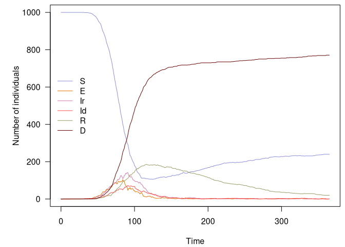

```r
x <- seirds_generator$new()


seirds_col <- c("#8c8cd9", "#e67300", "#d279a6", "#ff4d4d", "#999966", "#660000")

set.seed(1)
x_res <- x$run(0:365)
par(mar = c(4.1, 5.1, 0.5, 0.5), las = 1)
matplot(x_res[, 1], x_res[, -1], xlab = "Time", ylab = "Number of individuals",
        type = "l", col = seirds_col, lty = 1)
legend("left", lwd = 1, col = seirds_col, legend = c("S", "E", "Ir", "Id", "R", "D"), bty = "n")
```

Several runs can be obtained without rewriting the model, for instance, to get 100 replicates:

```r
x_res <- as.data.frame(replicate(100, x$run(0:365)[, -1]))
dim(x_res)
```

```
## [1] 366 600
```

```r
x_res[1:6, 1:10]
```

```
##    S.1 E.1 Id.1 Ir.1 R.1 D.1  S.2 E.2 Id.2 Ir.2
## 1 1000   1    0    0   0   0 1000   1    0    0
## 2 1000   1    0    0   0   0 1000   1    0    0
## 3 1000   0    0    1   0   0 1000   2    0    0
## 4 1000   0    0    1   0   0 1000   1    1    0
## 5 1000   0    0    1   0   0 1000   1    1    0
## 6 1000   0    0    1   0   0 1000   0    2    0
```

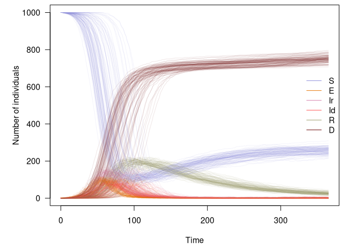

*100 replicates of a stochastic, discrete-time SEIRDS model*

```r
seirds_col_transp <- paste0(seirds_col, "1A")
par(mar = c(4.1, 5.1, 0.5, 0.5), las = 1)
matplot(0:365, x_res, xlab = "Time", ylab = "Number of individuals",
        type = "l", col = rep(seirds_col_transp, 100), lty = 1)
legend("right", lwd = 1, col = seirds_col,
       legend = c("S", "E", "Ir", "Id", "R", "D"), bty = "n")
```

It is then possible to explore the behaviour of the model using a simple function:

```r
check_model <- function(n = 50, t = 0:365, alpha = 0.2, ...,
                        legend_pos = "topright") {
  model <- seirds_generator$new(...)
  col <- paste0(seirds_col, "33")

  res <- as.data.frame(replicate(n, model$run(t)[, -1]))
  opar <- par(no.readonly = TRUE)
  on.exit(par(opar))
  par(mar = c(4.1, 5.1, 0.5, 0.5), las = 1)
  matplot(t, res, xlab = "Time", ylab = "",  type = "l",
          col = rep(col, n), lty = 1)
  mtext("Number of individuals", side = 2, line = 3.5, las = 3, cex = 1.2)
  legend(legend_pos, lwd = 1, col = seirds_col,
         legend = c("S", "E", "Ir", "Id", "R", "D"), bty = "n")
}
```

This is a sanity check with a null infection rate and no imported case:

```r
check_model(beta = 0, epsilon = 0)
```

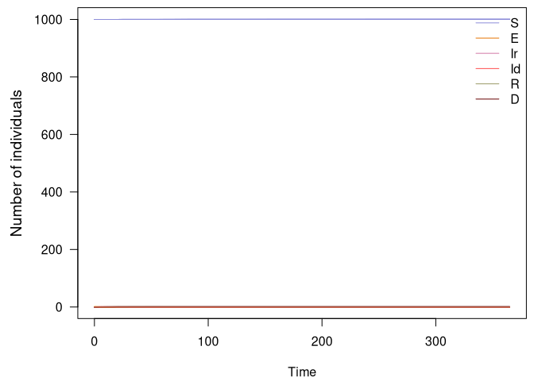

*Stochastic SEIRDS model: sanity check with no infections*

Another easy case: no importation, no waning immunity:

```r
check_model(epsilon = 0, omega = 0)
```

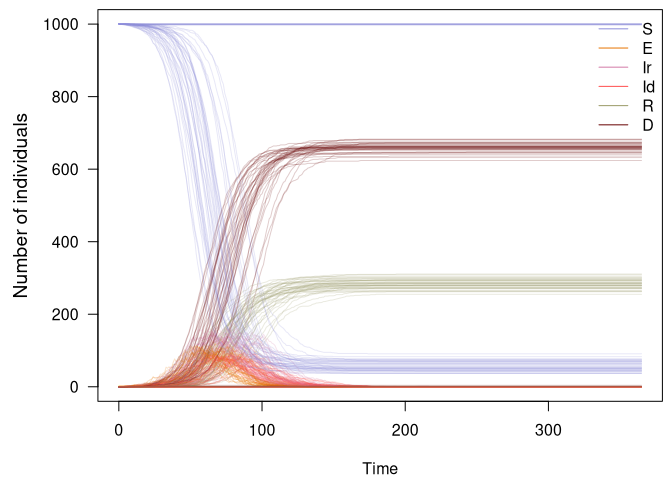

*Stochastic SEIRDS model: no importation or waning immunity*

A more nuanced case: persistence of the disease with limited import, waning immunity, low severity, larger population:

```r
check_model(t = 0:(365 * 3), epsilon = 0.1, beta = .2, omega = .01,
            mu = 0.005, S_ini = 1e5)
```

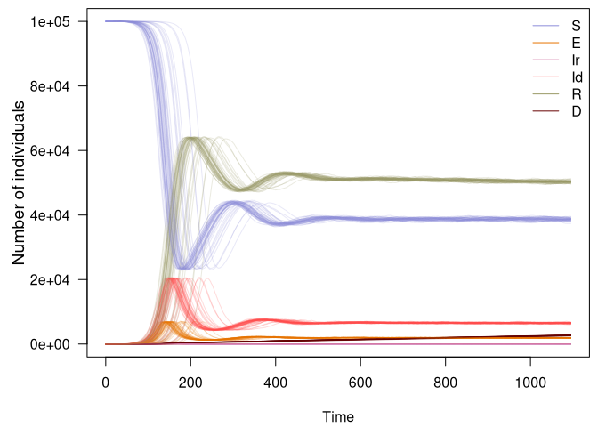

*Stochastic SEIRDS model: endemic state in a larger population*